# Notebook 06 – Solutions

## Getting Started

Before running this notebook, select “Session > Restart R and Clear Output” in the menu above to start a new R session. This will clear any old data sets and give us a blank slate to start with.

After starting a new session, run the following code chunk to load the libraries and data that we will be working with today.

I have set the options `include=FALSE` and `message=FALSE` to avoid cluttering the solutions with all the output from this code.

# Creating New Variables

## Mutate verb

The final core **dplyr** verb that we will look at is used to create a new variable in our data set based on other variables that are already present. This verb is called `mutate`, and works by giving it the name of the variable you want to create followed by the code that describes how to construct the variable in terms of the rest of the data.

As an example, consider computing the number of calories in an 200g portion of each food. All of the variables in the data set are currently given as 100g portions, so to compute this we need to multiply the `calories` variables by 2. To do this, we use the `mutate` verb to name and describe a new variable `calories_200g`.

```r
food %>%
  mutate(calories_200g = calories * 2)
```

```
## # A tibble: 61 x 18
##    item  food_group calories total_fat sat_fat cholesterol sodium carbs fiber
##    <chr> <chr>         <dbl>     <dbl>   <dbl>       <dbl>  <dbl> <dbl> <dbl>
##  1 Apple fruit            52       0.1   0.028           0      1 13.8    2.4
##  2 Aspa… vegetable        20       0.1   0.046           0      2  3.88   2.1
##  3 Avoc… fruit           160      14.6   2.13            0      7  8.53   6.7
##  4 Bana… fruit            89       0.3   0.112           0      1 22.8    2.6
##  5 Chic… grains          180       2.9   0.309           0    243 30.0    8.6
##  6 Stri… vegetable        31       0.1   0.026           0      6  7.13   3.4
##  7 Beef  meat            288      19.5   7.73           87    384  0      0
##  8 Bell… vegetable        26       0     0.059           0      2  6.03   2
##  9 Crab  fish             87       1     0.222          78    293  0.04   0
## 10 Broc… vegetable        34       0.3   0.039           0     33  6.64   2.6
## # … with 51 more rows, and 9 more variables: sugar <dbl>, protein <dbl>,
## #   iron <dbl>, vitamin_a <dbl>, vitamin_c <dbl>, wiki <chr>,
## #   description <chr>, color <chr>, calories_200g <dbl>
```

Notice that there is a new variable named `calories_200g` that has been added as the last column in the data set. Because it is added at the end of the data set, it gets hidden in the output shown above. Making use of `select` allows us to see the new values:

```r
food %>%
  mutate(calories_200g = calories * 2) %>%
  select(item, food_group, calories, calories_200g)
```

```
## # A tibble: 61 x 4
##    item        food_group calories calories_200g
##    <chr>       <chr>         <dbl>         <dbl>
##  1 Apple       fruit            52           104
##  2 Asparagus   vegetable        20            40
##  3 Avocado     fruit           160           320
##  4 Banana      fruit            89           178
##  5 Chickpea    grains          180           360
##  6 String Bean vegetable        31            62
##  7 Beef        meat            288           576
##  8 Bell Pepper vegetable        26            52
##  9 Crab        fish             87           174
## 10 Broccoli    vegetable        34            68
## # … with 51 more rows
```

And now we can see that the new column has been created by doubling the number given the `calories` column.

Note that `mutate` can also be used to modify any existing column in the data set by using the name of an extant variable. In this case the position of the variable within the tables does not change.

The mutate verb itself has a relatively straightforward syntax. The main challenge is knowing how to apply and chain together the various transformations that are useful within an analysis. In the next few sections, we highlight several common types of operations that we will be useful in subsequent applications.

## Conditional values

Many of the uses for the mutate verb involve assigning one value when a set of conditions is true and another if the conditions are false. For example, consider creating a new variable called `sugar_level` based on the relative amount of sugar in each food item. We might classify a food has having a “high” sugar level if has more than 10g of sugar per 100g serving, and a “normal” amount otherwise. In order to create this variable, we need the function `if_else`.

The `if_else` function has three parts: a TRUE/FALSE statement, the value to use when the statement is true, and the value to use when it is false. Here is an example to create our new variable:

```r
food %>%
  mutate(sugar_level = if_else(sugar > 10, "high", "normal")) %>%
  select(item, food_group, sugar, sugar_level)
```

```
## # A tibble: 61 x 4
##    item        food_group sugar sugar_level
##    <chr>       <chr>      <dbl> <chr>
##  1 Apple       fruit      10.4  high
##  2 Asparagus   vegetable   1.88 normal
##  3 Avocado     fruit       0.66 normal
##  4 Banana      fruit      12.2  high
##  5 Chickpea    grains      5.29 normal
##  6 String Bean vegetable   1.4  normal
##  7 Beef        meat        0    normal
##  8 Bell Pepper vegetable   4.2  normal
##  9 Crab        fish        0    normal
## 10 Broccoli    vegetable   1.7  normal
## # … with 51 more rows
```

Looking at the first rows of data, we see that apples and bananas are classified as high sugar foods, whereas the other sugar levels are given the sugar level category of “normal”.

The `if_else` function can be used to produce any number of categories by using it multiple times. Let’s modify our sugar level variable to now have three categories: “high” (over 10g), “low” (less than 1g), and “normal” (between 1g and 10g). There are several different ways to get to the same result, but I find the easiest is to start by assigning a default value and then changing the value of the new variable in sequence. For example, here some code that produces our new categories:

```r
food %>%
  mutate(sugar_level = "default") %>%
  mutate(sugar_level = if_else(sugar < 1, "low", sugar_level)) %>%
  mutate(sugar_level = if_else(sugar > 10, "high", sugar_level)) %>%
  mutate(sugar_level = if_else(between(sugar, 1, 10), "normal", sugar_level)) %>%
  select(item, food_group, sugar, sugar_level)
```

```
## # A tibble: 61 x 4
##    item        food_group sugar sugar_level
##    <chr>       <chr>      <dbl> <chr>
##  1 Apple       fruit      10.4  high
##  2 Asparagus   vegetable   1.88 normal
##  3 Avocado     fruit       0.66 low
##  4 Banana      fruit      12.2  high
##  5 Chickpea    grains      5.29 normal
##  6 String Bean vegetable   1.4  normal
##  7 Beef        meat        0    low
##  8 Bell Pepper vegetable   4.2  normal
##  9 Crab        fish        0    low
## 10 Broccoli    vegetable   1.7  normal
## # … with 51 more rows
```

In each `if_else` step we are telling the mutate function that if the condition is false set `sugar_level` equal to itself. In other words, if the condition does not hold, do not change the value of the variable.

In may wonder why we created a “default” value for the variable `sugar_level`. It would have been one less line of code to set the default value to “normal” and remove the final mutate function. The reason for the approach above is three-fold. First, it’s easier to understand what the code is doing in it’s current format because each condition (“high”, “normal”, and “low”) is explicitly coded. Secondly, it creates a nice check on our code and data. If we find a row of the output that still has the value “default” we will know that there is a problem somewhere. Finally, the code above will more safely handle the issues with missing values, and issue that we will return to shortly.

## Creating labels

Another common type of manipulation that is used with the mutate verb is the creation of a textual label. This can be done with the function `stri_paste`. It takes any number of inputs and combines them into a single string. We can mix both variables in the data set as well as fixed strings to create useful labels for data visualizations. For example, if we create a label variable describing each fruit and its sugar content:

```r
food %>%
  mutate(label = stri_paste(item, " (", sugar, "g)")) %>%
  select(item, sugar, label)
```

```
## # A tibble: 61 x 3
##    item        sugar label
##    <chr>       <dbl> <chr>
##  1 Apple       10.4  Apple (10.39g)
##  2 Asparagus    1.88 Asparagus (1.88g)
##  3 Avocado      0.66 Avocado (0.66g)
##  4 Banana      12.2  Banana (12.23g)
##  5 Chickpea     5.29 Chickpea (5.29g)
##  6 String Bean  1.4  String Bean (1.4g)
##  7 Beef         0    Beef (0g)
##  8 Bell Pepper  4.2  Bell Pepper (4.2g)
##  9 Crab         0    Crab (0g)
## 10 Broccoli     1.7  Broccoli (1.7g)
## # … with 51 more rows
```

The `label` variable could then be used as a textual label in a subsequent plot with textual data. This is similar to the `sm_paste` function that we saw when summarizing the values of a character vector.

## Factors

R has a special data type called a “factor” (abbreviated “fct”) that is specifically designed to handle categorical variables. It is typically not a good idea to store data as a factor because the resulting variables have some odd, error-producing, behaviors. However, it can be useful to create a factor as part of a mutate function just prior to creating a data visualizations.

For us, biggest difference between factors and character vectors is that a factor vector has a default ordered of its unique values, called the factor’s “levels”. Creating and understanding factors is useful because it allows us to change the ordering of categories within visualizations and models (which by default is done alphabetically).

One of the easiest ways to produce a factor variable with a given order is through the function `fct_inorder`. It will order the categories in the same order that they (first) appear in the data set. Combining this with the `arrange` function provides a lot of control over how categories become ordered. For example, the following code produces a bar plot of the food groups in our data set arranged from the largest category to the smallest category:

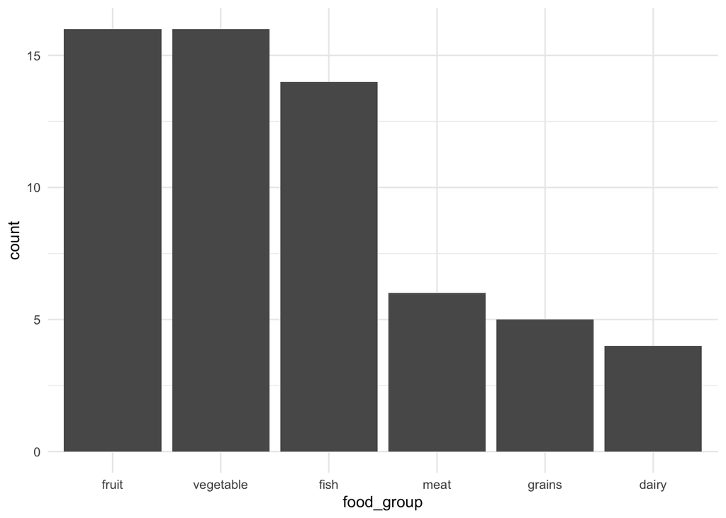

```r
food %>%
  group_by(food_group) %>%
  summarize(sm_count()) %>%
  arrange(desc(count)) %>%
  mutate(food_group = fct_inorder(food_group)) %>%
  ggplot() +
    geom_col(aes(food_group, count))
```

Other useful functions for manipulating categories include `fct_relevel` for manually putting one category first and `fct_lump_n` for combining together the smallest categories into a collective “Other” category.

## Mutate summaries

All of summary functions that were introduced in the previous notebook can also be applied within the mutate version. Instead of reducing the data to a single summary row, summarizing within the mutate verb duplicates the summary statistic in each row of the data set. Here is an example of including the average number of calories across all rows of the data set:

```r
food %>%
  mutate(sm_mean(calories))
```

```
## # A tibble: 61 x 18
##    item  food_group calories total_fat sat_fat cholesterol sodium carbs fiber
##    <chr> <chr>         <dbl>     <dbl>   <dbl>       <dbl>  <dbl> <dbl> <dbl>
##  1 Apple fruit            52       0.1   0.028           0      1 13.8    2.4
##  2 Aspa… vegetable        20       0.1   0.046           0      2  3.88   2.1
##  3 Avoc… fruit           160      14.6   2.13            0      7  8.53   6.7
##  4 Bana… fruit            89       0.3   0.112           0      1 22.8    2.6
##  5 Chic… grains          180       2.9   0.309           0    243 30.0    8.6
##  6 Stri… vegetable        31       0.1   0.026           0      6  7.13   3.4
##  7 Beef  meat            288      19.5   7.73           87    384  0      0
##  8 Bell… vegetable        26       0     0.059           0      2  6.03   2
##  9 Crab  fish             87       1     0.222          78    293  0.04   0
## 10 Broc… vegetable        34       0.3   0.039           0     33  6.64   2.6
## # … with 51 more rows, and 9 more variables: sugar <dbl>, protein <dbl>,
## #   iron <dbl>, vitamin_a <dbl>, vitamin_c <dbl>, wiki <chr>,
## #   description <chr>, color <chr>, calories_mean <dbl>
```

As with any call to mutate, all of the original variables are kept in the output and the new variable is added at the end. Using `select` we can verify that the average calories has in fact been added to each row of the table.

```r
food %>%
  mutate(sm_mean(calories)) %>%
  select(item, food_group, calories, calories_mean)
```

```
## # A tibble: 61 x 4
##    item        food_group calories calories_mean
##    <chr>       <chr>         <dbl>         <dbl>
##  1 Apple       fruit            52          114.
##  2 Asparagus   vegetable        20          114.
##  3 Avocado     fruit           160          114.
##  4 Banana      fruit            89          114.
##  5 Chickpea    grains          180          114.
##  6 String Bean vegetable        31          114.
##  7 Beef        meat            288          114.
##  8 Bell Pepper vegetable        26          114.
##  9 Crab        fish             87          114.
## 10 Broccoli    vegetable        34          114.
## # … with 51 more rows
```

The power of mutate summaries becomes particularly clear when grouping the data. If we group the data set by one or more variables and apply a summary function within a mutation, the repeated summaries will be done within each group. Here is an example of adding the average calories of each food group to the data set:

```r
food %>%
  group_by(food_group) %>%
  mutate(sm_mean(calories)) %>%
  select(item, food_group, calories, calories_mean)
```

```
## # A tibble: 61 x 4
## # Groups:   food_group [6]
##    item        food_group calories calories_mean
##    <chr>       <chr>         <dbl>         <dbl>
##  1 Apple       fruit            52          54.9
##  2 Asparagus   vegetable        20          37.4
##  3 Avocado     fruit           160          54.9
##  4 Banana      fruit            89          54.9
##  5 Chickpea    grains          180         196.
##  6 String Bean vegetable        31          37.4
##  7 Beef        meat            288         234.
##  8 Bell Pepper vegetable        26          37.4
##  9 Crab        fish             87         167.
## 10 Broccoli    vegetable        34          37.4
## # … with 51 more rows
```

Following this with a filter, for example, would allow us to select all of the foods that have a less than average number of calories within their food group. We will see many examples of grouped mutate summaries throughout our applications.

## Labels and themes

We have seen a number of ways to create and modify data visualizations. One thing that we did not cover was how to label our axes. While many data visualization guides like to stress the importance of labelling axes, while in the exploratory phase of analysis it is often best to simply use the default labels provided by R. These are useful for a number of reasons. First, they require minimal effort and make it easy to tweak axes, variables, and other settings without spending time tweaking with the labels. Secondly, the default labels use the variable names in our dataset. When writing code this is *exactly* what we need to know about a variable to use it in additional plots, models, and data manipulation tasks. Of course, once we want to present our results to others, it is essential to provide more detailed descriptions of the axes and legends in our plot. Fortunately, this is relatively easy using the grammar of graphics.

In order to change the labels in a plot, we can use the `labs` function as an extra part of our plot. Inside the function, we assign labels to the names of aes values that you want to describe. Leaving a value unspecified will keep the default value in place. Labels for the x-axis and y-axis will be go on the sides of the plot. Labels for other aesthetics such as size and color will be placed in the legend. Here is an example of a scatterplot with labels for the three aesthetics:

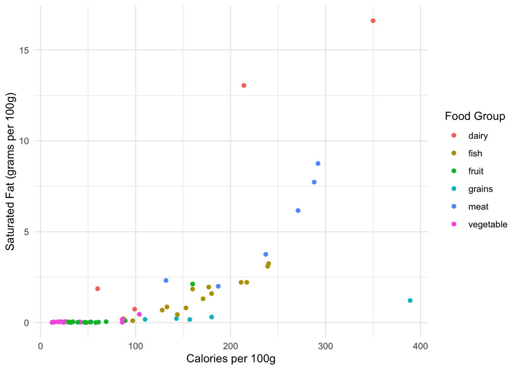

```r
food %>%
  ggplot() +
    geom_point(aes(x = calories, y = sat_fat, color = food_group)) +
    labs(
      x = "Calories per 100g",
      y = "Saturated Fat (grams per 100g)",
      color = "Food Group"
    )
```

Notice that the descriptions inside of the `labs` function is fairly long. The code here breaks it up by putting each argument on its own line (indented a further two spaces). This is good practice when using functions with a lot of arguments.

We can also had a title (and optional subtitle and caption) to the plot by adding these as named arguments to the `labs` function.

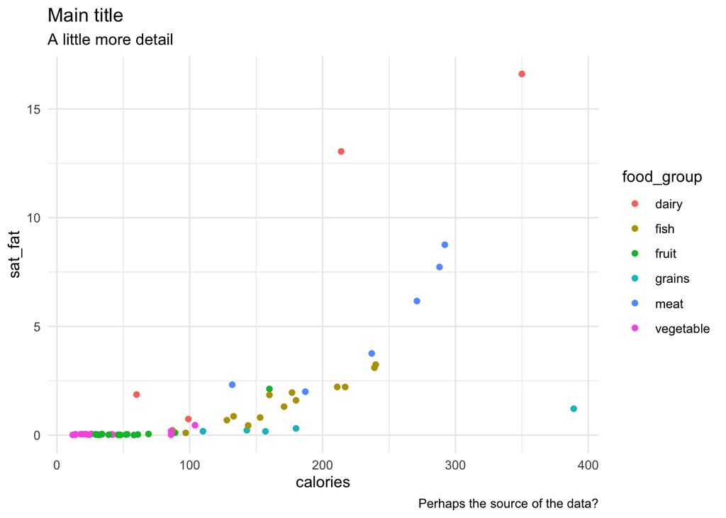

```r
food %>%
  ggplot() +
    geom_point(aes(x = calories, y = sat_fat, color = food_group)) +
    labs(
      title = "Main title",
      subtitle = "A little more detail",
      caption = "Perhaps the source of the data?"
    )
```

Another way to prepare our graphics for publication is to modify the *theme* of a plot. Themes effect the way that the plot elements such as the axis labels, ticks, and background look. By default through this book, we have set the default plot to `theme_minimal`. I think that this is a great choice for exploration of a dataset. As the name implies, it removes most of the clutter of other choices while keeping grid lines and other visual cues to help interpret a dataset. When presenting information for external publication, I prefer to use the theme called `theme_sm` based on the work of Edward Tufte. To set the theme, just call the following line of code sometime before making your plot:

```r
theme_set(theme_sm())
```

Now, when we construct a plot it will use the newly assigned theme:

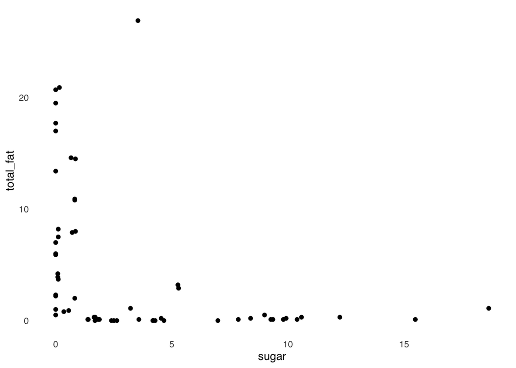

```r
food %>%
  ggplot() +
    geom_point(aes(x = sugar, y = total_fat))
```

The Tufte theme is designed to use as little “ink” as possible, thus focusing the reader on the data. It can be a bit too minimal when first exploring the dataset, but is a great tool for presenting your results.

# Practice

## Load Datasets

We will work with the largest cities datasets:

```r
theme_set(theme_minimal())

cities <- read_csv(file.path("data", "largest_cities.csv"))
```

We will also work with the entire U.S. cities dataset:

```r
us <- read_csv(file.path("data", "us_city_population.csv"))
```

Please refer to notebook02a for more information about these datasets and how these datasets are organized.

## Creating new numeric variables

Using the `cities` dataset, create a new variable named `city_density` by dividing the city population (`city_pop`) by the city area (`city_area`). Use the `select` function to select the city name (`name`), population, area, and density.

```r
cities %>%
  mutate(city_density = city_pop / city_area) %>%
  select(name, city_pop, city_area, city_density)
```

```
## # A tibble: 81 x 4
##    name        city_pop city_area city_density
##    <chr>          <dbl>     <dbl>        <dbl>
##  1 Tokyo          13.5       2191      0.00617
##  2 Delhi          16.8       1484      0.0113
##  3 Shanghai       24.2       6341      0.00381
##  4 São Paulo      12.3       1521      0.00806
##  5 Mexico City     8.92      1485      0.00601
##  6 Cairo           9.5       3085      0.00308
##  7 Mumbai         12.5        603      0.0207
##  8 Beijing        21.7      16411      0.00132
##  9 Dhaka          14.4        338      0.0426
## 10 Osaka           2.72       225      0.0121
## # … with 71 more rows
```

The numbers here are very small. What units is the variable `city_density` currently in? **Answer**: It is given in millions of people per square kilometer.

Below, modify your code by multiplying the city density by 1000.

```r
cities %>%
  mutate(city_density = city_pop / city_area * 1000) %>%
  select(name, city_pop, city_area, city_density)
```

```
## # A tibble: 81 x 4
##    name        city_pop city_area city_density
##    <chr>          <dbl>     <dbl>        <dbl>
##  1 Tokyo          13.5       2191         6.17
##  2 Delhi          16.8       1484        11.3
##  3 Shanghai       24.2       6341         3.81
##  4 São Paulo      12.3       1521         8.06
##  5 Mexico City     8.92      1485         6.01
##  6 Cairo           9.5       3085         3.08
##  7 Mumbai         12.5        603        20.7
##  8 Beijing        21.7      16411         1.32
##  9 Dhaka          14.4        338        42.6
## 10 Osaka           2.72       225        12.1
## # … with 71 more rows
```

Now what are the units of the city density variable? **Answer**: Thousands of people per square kilometer.

Now, summarize the average city density by continent.

```r
cities %>%
  mutate(city_density = city_pop / city_area * 1000) %>%
  group_by(continent) %>%
  summarize(sm_mean(city_density))
```

```
## # A tibble: 5 x 2
##   continent     city_density_mean
##   <chr>                     <dbl>
## 1 Africa                     5.21
## 2 Asia                      10.6
## 3 Europe                     9.26
## 4 North America              3.87
## 5 South America              7.87
```

Now, below, using the mutate verb, create a plot with city density on the x-axis and metro density on the y-axis. Use a log scale for the axes and include points and text repel labels with the city names.

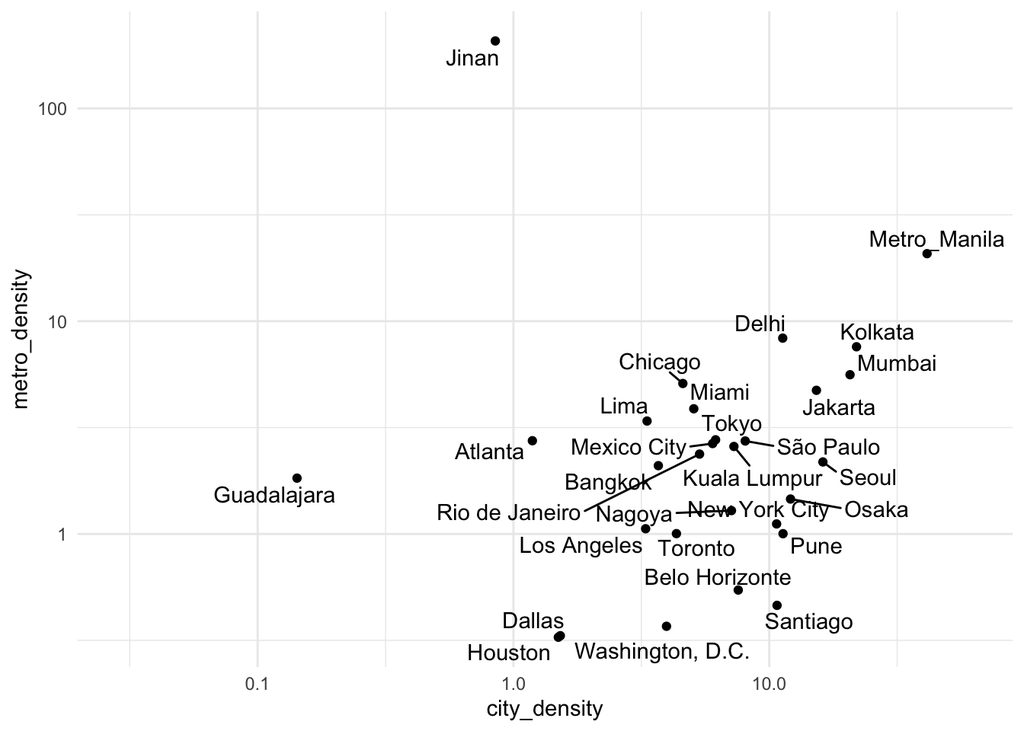

```r
cities %>%
  mutate(city_density = city_pop / city_area * 1000) %>%
  mutate(metro_density = metro_pop / metro_area * 1000) %>%
  ggplot(aes(city_density, metro_density)) +
    geom_point() +
    geom_text_repel(aes(label = name)) +
    scale_x_log10() +
    scale_y_log10()
```

What two outliers stick out in this plot? **Answer**: Guadalajara and Jinan have a much higher metro density than would be expect based on the city density.

## Creating new categorical variables

Create a bar plot showing the counts of the the `koppen_code` variable in the `cities` dataset. Order the groups categories ordered from the biggest to the smallest. The labels are short so there should be no need to flip the axes in the plot.

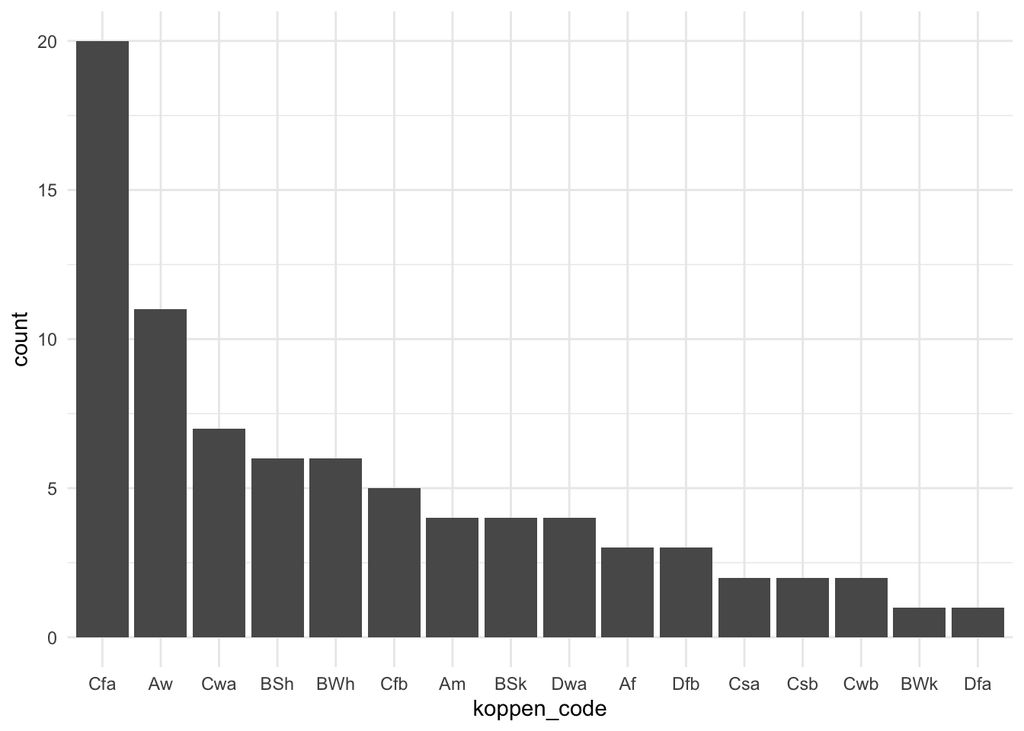

```r
cities %>%
  group_by(koppen_code) %>%
  summarize(sm_count()) %>%
  arrange(desc(count)) %>%
  mutate(koppen_code = fct_inorder(koppen_code)) %>%
  ggplot(aes(koppen_code, count)) +
    geom_col()
```

In the code below, create a new variable called `hemisphere` which is equal to “North” for cities with a latitude above zero and “South” for cities below zero. Pipe the data to a plot and color the cities by their hemisphere to verify that your code is correct.

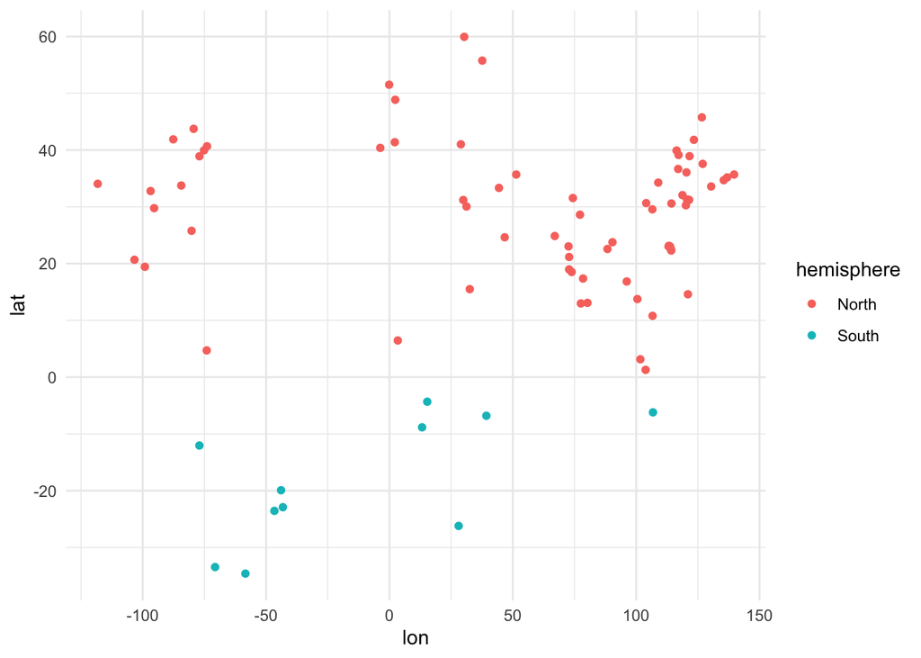

```r
cities %>%
  mutate(hemisphere = if_else(lat > 0, "North", "South")) %>%
  ggplot(aes(lon, lat)) +
    geom_point(aes(color = hemisphere))
```

Repeat this process below, but this time create a variable called “quadrant” that is equal to “NE”, “NW”, “SE”, and “SE” depending on the sign of the latitude and longitude variables. The easiest way to do this is to start by defining a default value and them fill in the quadrants with four uses of the `if_else` function. Note: use the `&` operator to combine two conditions (i.e., `(lat > 0) & (lon > 0)`).

As above, pipe the data into a plot colored by quadrant to verify your work.

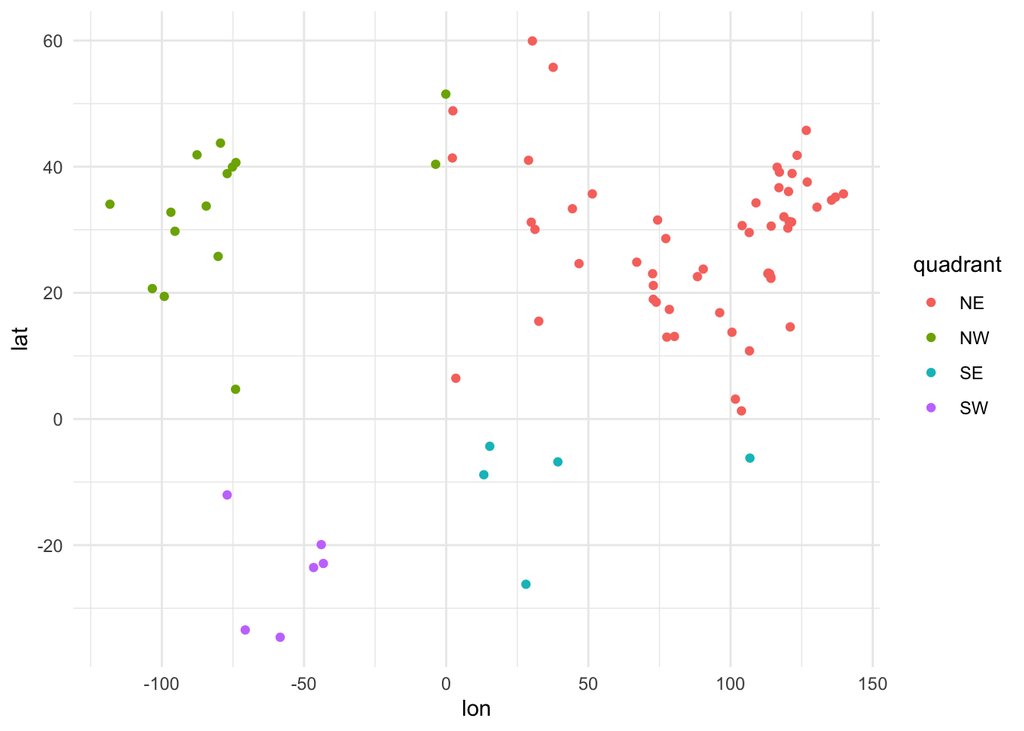

```r
cities %>%
  mutate(quadrant = "default") %>%
  mutate(quadrant = if_else((lat > 0) & (lon > 0), "NE", quadrant)) %>%
  mutate(quadrant = if_else((lat > 0) & (lon < 0), "NW", quadrant)) %>%
  mutate(quadrant = if_else((lat < 0) & (lon > 0), "SE", quadrant)) %>%
  mutate(quadrant = if_else((lat < 0) & (lon < 0), "SW", quadrant)) %>%
  ggplot(aes(lon, lat)) +
    geom_point(aes(color = quadrant))
```

## Grouped Mutate

To conclude, we will apply a few grouped versions of the mutate verb. To make sure we understand how this works, take the `us` dataset, group by city, and compute the maximum value of the population variable for each city.

```r
us %>%
  group_by(city) %>%
  mutate(sm_max(population))
```

```
## # A tibble: 6,900 x 7
## # Groups:   city [300]
##    city            state  year population    lon   lat population_max
##    <chr>           <chr> <dbl>      <dbl>  <dbl> <dbl>          <dbl>
##  1 Anchorage, AK   AK     1790          0 -149.   61.2           292.
##  2 Birmingham, AL  AL     1790          0  -86.8  33.5           341.
##  3 Huntsville, AL  AL     1790          0  -86.5  34.8           180.
##  4 Mobile, AL      AL     1790          0  -88.1  30.7           200.
##  5 Montgomery, AL  AL     1790          0  -86.3  32.3           206.
##  6 Little Rock, AR AR     1790          0  -92.4  34.7           194.
##  7 Chandler, AZ    AZ     1790          0 -112.   33.3           236.
##  8 Gilbert, AZ     AZ     1790          0 -112.   33.3           208.
##  9 Glendale, AZ    AZ     1790          0 -112.   33.5           227.
## 10 Mesa, AZ        AZ     1790          0 -112.   33.4           439.
## # … with 6,890 more rows
```

Note that this added a new column to a copy of the original dataset showing the largest population for each city at any point in time.

Building off of this approach, construct a scatter plot that shows the population of cities in 2010 on the x-axis and the percentage of the 2010 population compared to the maximum population of the city from 1790-2010. Filter to only include cities that are less than 70% of their maximum size in 2010. Use a text repel layer to label each city. (Note: This will require at least two different calls to the mutate function).

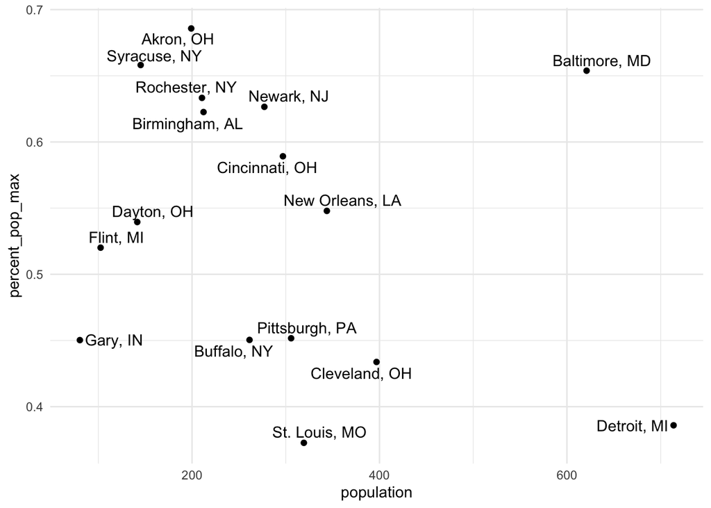

```r
us %>%
  group_by(city) %>%
  mutate(sm_max(population)) %>%
  filter(year == 2010) %>%
  mutate(percent_pop_max = population / population_max) %>%
  filter(percent_pop_max < 0.7) %>%
  ggplot(aes(population, percent_pop_max)) +
    geom_point() +
    geom_text_repel(aes(label = city))
```

## Labels and themes

In the code block below, create a visualization of the `cities` data with city population on the x-axis, city area on the y-axis, points colored by continent, and the point size given by the cities population density. Include informative labels (with units, where needed) for the axes and legends, a title, subtitle, and caption. Set the `theme_sm` theme and add logarithmic scales for the x and y axes.

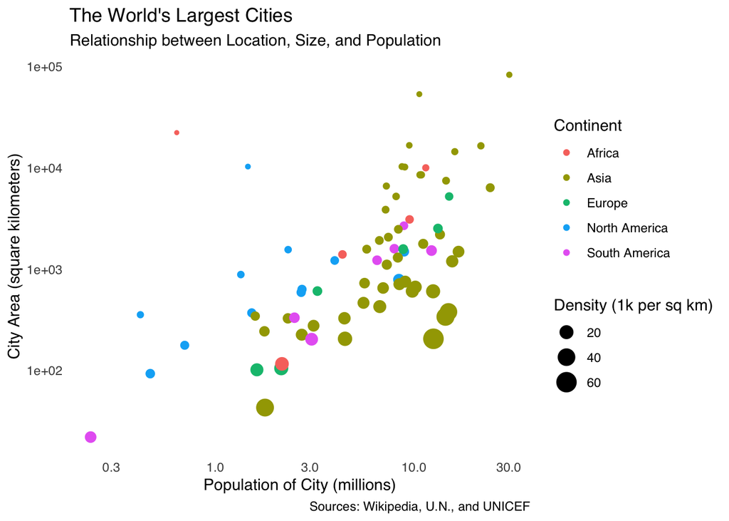

```r
theme_set(theme_sm())

cities %>%
  mutate(city_density = city_pop / city_area * 1000) %>%
  ggplot(aes(city_pop, city_area)) +
    geom_point(aes(color = continent, size = city_density)) +
    scale_x_log10() +
    scale_y_log10() +
    labs(
      x = "Population of City (millions)",
      y = "City Area (square kilometers)",
      color = "Continent",
      size = "Density (1k per sq km)",
      title = "The World's Largest Cities",
      subtitle = "Relationship between Location, Size, and Population",
      caption = "Sources: Wikipedia, U.N., and UNICEF"
    )
```